# Mini-Project 4: Forecasting Team USA’s Performance at the 2028 LA Olympics

Author

Mary Lycke

Published

May 15, 2026

This report aims to forecast how Team USA will perform at the 2028 Olympic Games in Los Angeles. The forecast has three main factors: typical USA Olympic Games performance, the effect of being the host nation on performance, and the effect of adding host-chosen new sports on performance. All data for the forecast has been sourced from Olympedia.

To access the data for this forecast, we scraped Olympedia’s editions index, extracting year, season, city, and URL for all 60 modern Olympic Games.

| edition_id | year | season | city | url | notes |
| --- | --- | --- | --- | --- | --- |
| 1 | 1896 | Summer | Athina | /editions/1 |  |
| 2 | 1900 | Summer | Paris | /editions/2 |  |
| 3 | 1904 | Summer | St. Louis | /editions/3 |  |
| 4 | 1908 | Summer | London | /editions/5 |  |
| 5 | 1912 | Summer | Stockholm | /editions/6 |  |
| 6 | 1916 | Summer | Berlin | /editions/50 | Not held due to war |
| 7 | 1920 | Summer | Antwerpen | /editions/7 |  |
| 8 | 1924 | Summer | Paris | /editions/8 |  |
| 9 | 1928 | Summer | Amsterdam | /editions/9 |  |
| 10 | 1932 | Summer | Los Angeles | /editions/10 |  |

[output cut: 52 more lines]

After scraping the data, we discovered that there were 68 mismatches between NOC and ISO codes, including direct renames (e.g. GER to DEU, GRE to GRC), now-defunct states (e.g. URS/EUN/ROC to RUS, GDR/FRG to DEU, etc) and some teams the were not affiliated with any single participating nation (dropped from the analysis).

The map below shows the total medals won per country on a log scale. Countries in gray have not won any medals. Wealthy, densely populated countries with longstanding participation rates dominate the Olympic Games.

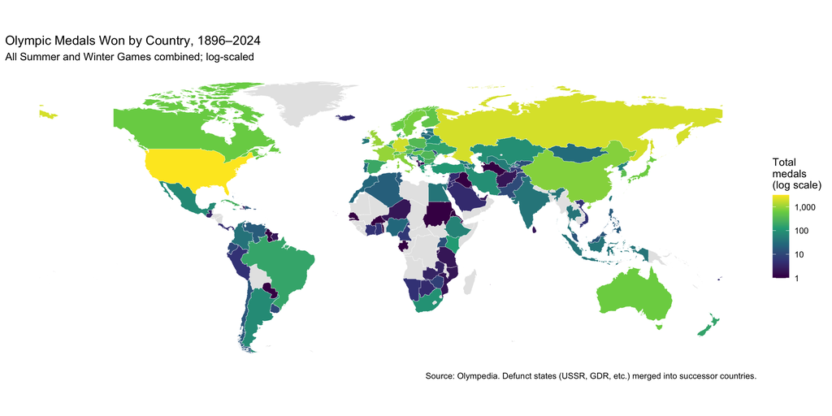

## Exploring the Three Effects

The following sections will outline Team USA’s baseline performance, how being the host country and introducing new sports as the host country impacts performance, as well as some additional caveats.

### USA Baseline Performance

The foundation for the forecast will be how the United States typically perform at the Olympics.

**Finding 1: Total Medals**

Across all modern Olympics from 1896 to 2024, Team USA has won 3,145 total medals, leading the second-place country, Russia, by 1,139 medals. The top-performing countries of all time include the United States, Russia, Germany, Britain, and France.

Top 5 countries by total Olympic medals, 1896–2024.

| Country | Total medals |
| --- | --- |
| USA | 3145 |
| RUS | 2006 |
| DEU | 1898 |
| GBR | 1031 |
| FRA | 998 |

**Finding 2: Trajectory Over Time**

The chart below shows USA medal count by Olympic Games, separated by season. Notable spikes include the 1904 Games in St. Louis and the 1984 Games in Los Angeles. There is a generally steady upward trend in performance.

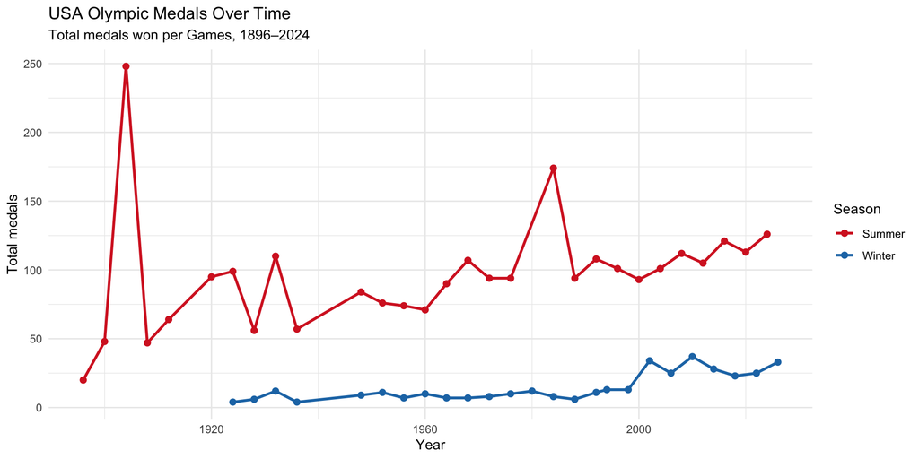

**Finding 3: Strongest Disciplines**

Top 10 USA disciplines by total medals.

| Discipline | Gold | Silver | Bronze | Total | Games contested |
| --- | --- | --- | --- | --- | --- |
| Athletics | 358 | 281 | 224 | 863 | 29 |
| Swimming | 266 | 195 | 153 | 614 | 27 |
| Wrestling | 59 | 47 | 43 | 149 | 26 |
| Diving | 48 | 46 | 45 | 139 | 24 |
| Artistic Gymnastics | 43 | 46 | 43 | 132 | 16 |
| Shooting | 58 | 34 | 29 | 121 | 24 |
| Boxing | 50 | 27 | 41 | 118 | 25 |
| Rowing | 34 | 32 | 25 | 91 | 25 |
| Speed Skating | 32 | 24 | 20 | 76 | 22 |
| Sailing | 19 | 23 | 20 | 62 | 19 |

Team USA has historically performed the strongest in Athletics (or Track & Field) and Swimming, with 863 and 614 medals in each even respectively.

### Host Country Effect

Host nations are thought to outperform the competition, with a number of theories for why, including psychological boost, automatic event qualification, and just general enthusiasm.

**Finding 4: Average Boost**

Average medals per country-Games, host years vs. non-host years.

| Hosted? | Average medals | N country-Games |
| --- | --- | --- |
| FALSE | 10.6 | 1822 |
| TRUE | 45.0 | 54 |

On average, host countries win **45** , compared to **10.6** in Games they don’t host, a ratio of roughly 4.2x. Some of this can be chalked up to wealthier nations both hosting and winning more often, but even considering this the gap is still meaningful.

**Finding 5: Country-by-Country Comparison**

This chart shows host (red) vs. non-host (gray) averages for every country that has ever hosted an Olympic Games.

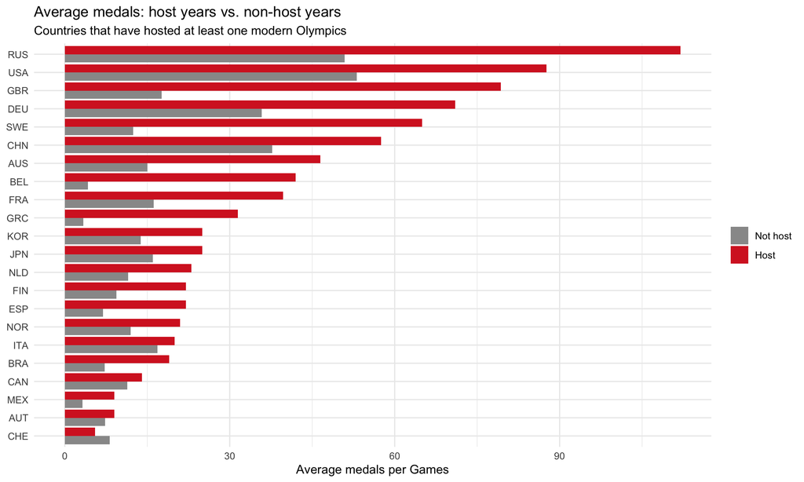

**Finding 6: Boost by Country**

Host country effect, by country.

| Country | Avg when hosting | Avg when not hosting | Times hosted | Boost |
| --- | --- | --- | --- | --- |
| GBR | 79.3 | 17.6 | 3 | 61.7 |
| RUS | 112.0 | 50.9 | 2 | 61.1 |
| SWE | 65.0 | 12.4 | 1 | 52.6 |
| BEL | 42.0 | 4.2 | 1 | 37.8 |
| DEU | 71.0 | 35.9 | 3 | 35.1 |
| USA | 87.6 | 53.1 | 8 | 34.5 |
| AUS | 46.5 | 15.0 | 2 | 31.5 |
| GRC | 31.5 | 3.4 | 2 | 28.1 |
| FRA | 39.7 | 16.2 | 6 | 23.5 |
| CHN | 57.5 | 37.7 | 2 | 19.8 |
| ESP | 22.0 | 6.9 | 1 | 15.1 |
| FIN | 22.0 | 9.4 | 1 | 12.6 |
| BRA | 19.0 | 7.2 | 1 | 11.8 |
| NLD | 23.0 | 11.5 | 1 | 11.5 |
| KOR | 25.0 | 13.8 | 2 | 11.2 |
| NOR | 21.0 | 12.0 | 2 | 9.0 |
| JPN | 25.0 | 16.0 | 4 | 9.0 |
| MEX | 9.0 | 3.2 | 1 | 5.8 |
| ITA | 20.0 | 16.9 | 4 | 3.1 |
| CAN | 14.0 | 11.3 | 3 | 2.7 |
| AUT | 9.0 | 7.3 | 2 | 1.7 |
| CHE | 5.5 | 8.2 | 2 | -2.7 |

USA’s hosting boost: 34.5 medals USA times hosted: 8 Top boost country: GBR

### New Sport Effect

For each Olympic Games, hosts are allowed to introduce up to 6 new sports, often choosing events they are traditionally strong in. This analysis focuses on new sports added from 1980 onwards since sports that are now considered traditional were introduced to the games incrementally before then.

**Finding 7: Average Host Share**

Host country medal share in newly-introduced disciplines, 1980 onward.

| Average host share | Number of new disciplines |
| --- | --- |
| 0.144 | 25 |

Across the **25** disciplines newly introduced between 1980 and 2026, host countries won an average of **14.4%** of available medals.

**Finding 8: Performance by Games**

This chart shows each host’s average medal share across new disciplines between 1960 and 2026.

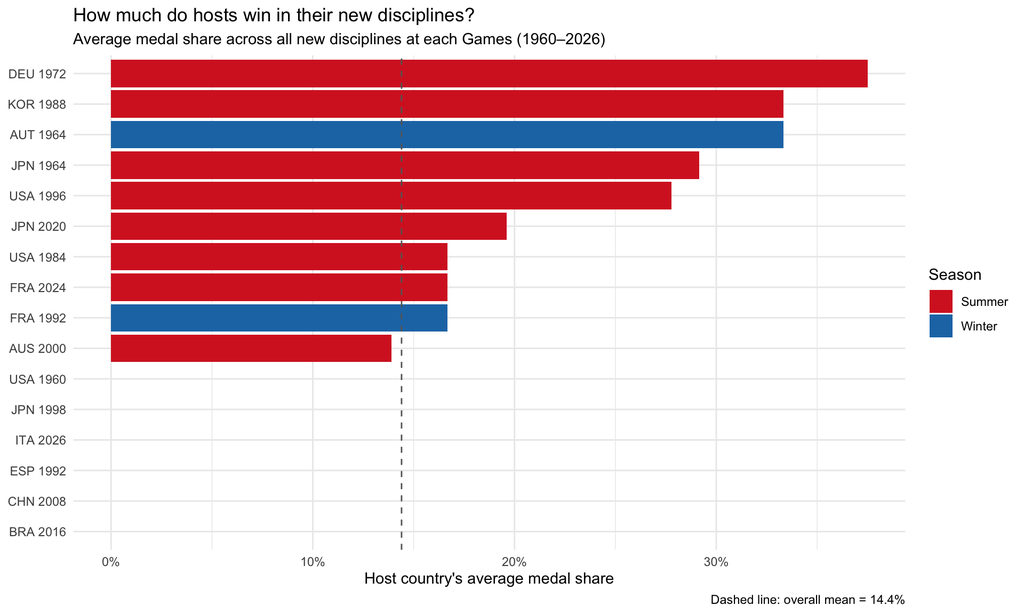

**Finding 9: Recent New Disciplines**

Recent new sports include skateboarding, sport climbing, surfing, and breaking.

Host country performance in newly-introduced disciplines, 2000–present.

| Year | Season | Host | Discipline | Host medals | Total medals | Host share |
| --- | --- | --- | --- | --- | --- | --- |
| 2026 | Winter | ITA | Ski Mountaineering | 0 | 8 | 0.0% |
| 2024 | Summer | FRA | Breaking | 1 | 6 | 16.7% |
| 2020 | Summer | JPN | Skateboarding | 5 | 12 | 41.7% |
| 2020 | Summer | JPN | Sport Climbing | 2 | 6 | 33.3% |
| 2020 | Summer | JPN | Surfing | 2 | 6 | 33.3% |
| 2020 | Summer | JPN | Karate | 3 | 32 | 9.4% |
| 2020 | Summer | JPN | 3x3 Basketball | 0 | 6 | 0.0% |
| 2020 | Summer | JPN | Cycling BMX Freestyle | 0 | 6 | 0.0% |
| 2016 | Summer | BRA | Rugby Sevens | 0 | 6 | 0.0% |
| 2008 | Summer | CHN | Cycling BMX Racing | 0 | 6 | 0.0% |
| 2008 | Summer | CHN | Marathon Swimming | 0 | 6 | 0.0% |
| 2000 | Summer | AUS | Trampolining | 1 | 6 | 16.7% |
| 2000 | Summer | AUS | Triathlon | 1 | 6 | 16.7% |
| 2000 | Summer | AUS | Taekwondo | 2 | 24 | 8.3% |

### Important Caveats

**Finding 10: Boycott Distortion**

USA Summer Olympic medals around the boycott era. 1980 omitted — USA did not participate.

| Year | USA medals | USA hosted? |
| --- | --- | --- |
| 1972 | 94 | FALSE |
| 1976 | 94 | FALSE |
| 1984 | 174 | TRUE |
| 1988 | 94 | FALSE |

There are several years Team USA’s performance was likely impacts by boycotts, including in 1984 when the United States hosted and the Soviet Union boycotted the Games. Additionally, the United States did not particpate in the 1980 Games.

**Finding 11: Medal Inflation**

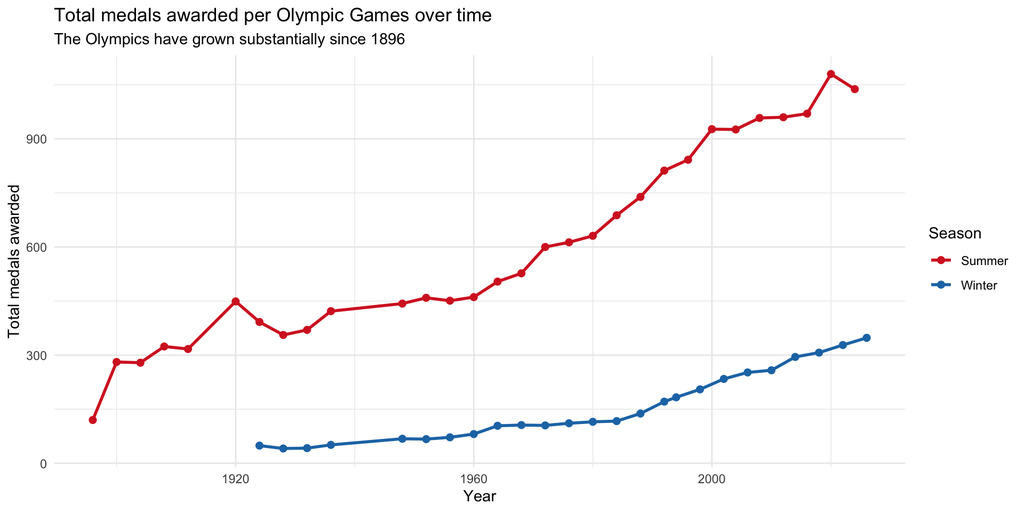

Summer total medals grew from 812 in 1992 to 1038 in 2024, showing 27.8% inflation.

**Finding 12: USA’s Record in New Sports**

Software was the dominant new sport, followed by baseball. Team USA won one silver medal in lacrosse in 1904, while the other three sports, cricket, flag football, and squash, have never been played at the Olympic Games.

USA’s historical performance in sports returning or being introduced for LA 2028.

| Discipline | Olympic appearances | Gold | Silver | Bronze | Total medals |
| --- | --- | --- | --- | --- | --- |
| Softball | 5 | 3 | 2 | 0 | 5 |
| Baseball | 4 | 1 | 1 | 2 | 4 |
| Lacrosse | 1 | 0 | 1 | 0 | 1 |

## Quantifying the Effects

**USA baseline**

Average USA medals at a Summer Olympics, with 95% confidence intervals (1960–2024).

| Medal type | Estimate | Lower 95% CI | Upper 95% CI |
| --- | --- | --- | --- |
| Gold | 41.5 | 35.1 | 47.9 |
| Silver | 34.3 | 29.2 | 39.4 |
| Bronze | 30.7 | 27.3 | 34.1 |
| Total | 106.5 | 94.6 | 118.4 |

**Host effect (% change)**

Host country medal boost, expressed as percent change over the prior same-season Games (1960–2024).

| Medal type | % increase | Lower 95% CI (%) | Upper 95% CI (%) |
| --- | --- | --- | --- |
| Gold | 191.9 | 84.9 | 298.8 |
| Silver | 75.3 | 21.3 | 129.3 |
| Bronze | 38.0 | 11.9 | 64.0 |
| Total | 72.3 | 37.9 | 106.6 |

**New sport effect**

Probability the host country wins a medal of each type in a newly-introduced discipline (1960–2024).

| Medal type | Lower 95% CI | Upper 95% CI |
| --- | --- | --- |
| Gold | 0.224 | 0.577 |
| Silver | 0.278 | 0.637 |
| Bronze | 0.149 | 0.482 |
| Any | 0.393 | 0.749 |

## Building the Forecast

The forecast equation:

$$\text{Medals}_{2028} \approx \text{USA Baseline} \times \text{Host Factor} + 22 \times P(\text{Host wins in new sport})$$

where the “22” reflects the 22 additional medal events at LA 2028.

Team USA is predicted to win 196 medals at the 2028 Summer Olympics in Los Angeles.

USA medal forecast for the 2028 Los Angeles Summer Olympics, with 95% confidence intervals (Monte Carlo simulation, n = 10 million).

| Medal type | Point estimate | Lower 95% CI | Upper 95% CI |
| --- | --- | --- | --- |
| Gold | 130 | 83 | 180 |
| Silver | 70 | 50 | 92 |
| Bronze | 49 | 40 | 59 |
| Total | 196 | 155 | 240 |

This forecast tells us that Team USA typically performs extremely well at the Olympic Games, but they are expected to perform even better at the 2028 Summer Olympics in Los Angeles due to both the host country and new sport advantages.

# Brief: Team USA at LA 2028

**FOR: LA 2028 Organizing Committee Fundraising Team**  
**RE: Team USA 2028 Medal Performance Forecast**

### The Headline

Our forecast shows that Team USA will win 196 medals at the 2028 Los Angeles Olympic Games, with the range being between 155 and 240 medals, as compared to the 126 medals won at the 2024 Paris Olympics. Our model outlines that even if Team USA performs on the lower end of the predicted range, 155 would still be among Team USA’s best-ever performances.

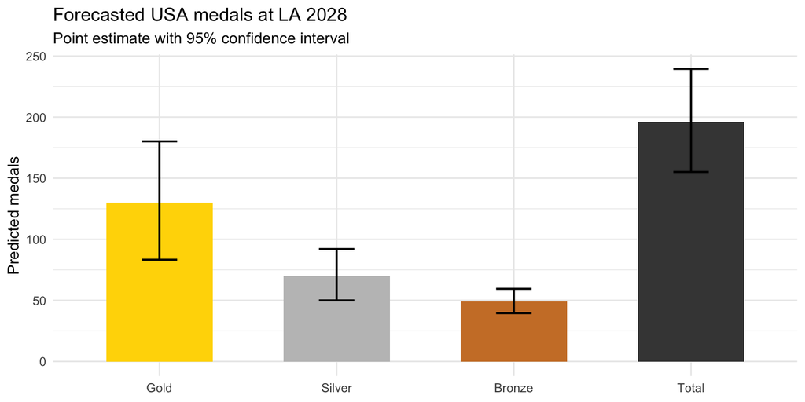

### Three Factors Drive This Forecast

#### Factor 1: USA Is the Perennial Olympic Powerhouse

Team USA has won 3,145 Olympic medals to date, 1,139 more medals than the second best performing country and an average of 42 gold medals per Summer Games since 1960. Athletics and Swimming are Team USA’s top performing events, both which draw a lot of viewers.

#### Factor 2: Host Nations Dramatically Outperform

Historically, host countries win 192% more gold medals than at prior Games. Russia won 33 medals at the 2014 Games in Sochi, compared to the 15 medals won in 2010 in Vancouver.

#### Factor 3: New Sports Favor the Host

Five new sports will be introduced at the 2028 Los Angeles Games: baseball/softball, cricket, flag football, lacrosse, and squash, adding 22 medal events. To date, Team USA has won 5 of 5 possible medals in softball and have performed well in baseball in previous Olympics.

### The Combined Forecast

With Team USA historically good performance, the host nation advantage, and five new sports added to the games chosen by the United States, the following shows expected performance.

USA 2028 medal forecast (95% confidence intervals).

| Medal type | Best estimate | Lower bound | Upper bound |
| --- | --- | --- | --- |
| Gold | 130 | 83 | 180 |
| Silver | 70 | 50 | 92 |
| Bronze | 49 | 40 | 59 |
| Total | 196 | 155 | 240 |

### The Sponsorship Opportunity

Team USA is essentially guaranteed to make historic gains at the 2028 Los Angeles Olympics, with even the most conservative estimate at 155 medals being exceptional. The combination of historical top-tier performance and the advantages of hosting the Games and choosing five new events matter.

*Forecast methodology: Estimates derived from 60+ Olympic Games of historical data sourced from Olympedia, combined via Monte Carlo simulation (10 million iterations) of three independently-estimated effects: USA baseline performance, host nation boost, and new-sport medal probability. All confidence intervals are at the 95% level.*

**NoteAI Usage Statement**

Claude was used to help write the code in this project, but all non-code text was generated without the use of any Generative AI tools. Additionally, Claude was used to provide additional background information on the topic and to brainstorm ideas for the final open-ended prompt.